# POP77001 Final Project

```python
# import external libraries
import pandas as pd
import matplotlib.pyplot as plt
import statistics
import random
```

# Part 1: Implement Clustering Algorithm

```python
class Kmeans:
    # intialise the class
    def __init__(self, k, seed=None, max_iterations=100):

        # define the internal variables
        self.k = k
        self.max_iterations = max_iterations
        self.centroids = None
        self.cluster_ids = None

        # if a seed is provided
        if seed is not None:
            # set the seed
            random.seed(seed)


    # define the internal functions
    # -----------------------------

    def get_distance(self, point, centroid):

        # calculate Euclidean distance
        return statistics.fsum((x - y) ** 2 for x, y in zip(point, centroid)) ** 0.5

    def get_centroid(self, cluster):

        # calculate the mean of the points in the cluster
        return [sum(points) / len(points) for points in zip(*cluster)]


    def k_means(self, data):


        # handle incorrect inputs
        # -----------------------

        # if data is not in list format
        if not isinstance(data, list):

                try:
                    # try to convert to list
                    data = data.values.tolist()

                # if this fails raise error
                except AttributeError:
                    raise ValueError("Input data must be a list or a DataFrame")

        # if the data is empty
        if len(data) == 0:
            # raise error
            raise ValueError("Input data cannot be empty.")

        # if k is not an integer
        if not isinstance(self.k, int):
            try:
                 # try and convert it to integer
                self.k = int(self.k)

            # raise error is k cannot be converted
            except ValueError:
                # catch the ValueError to show specific message
                raise ValueError("k must be an integer.")


        # start the clustering algorithm
        # ----------------------------------

        # choose k random centroids
        self.centroids = random.sample(data, self.k)

        # begin k means algorithm
        for _ in range(self.max_iterations):

            # create k empty clusters
            clusters = {i: [] for i in range(self.k)}

            # loop through all the data points
            for point in data:

                # calculate distances from point to all centroids
                distances = [self.get_distance(point, centroid) for centroid in self.centroids]

                # select the closest centroid
                closest_centroid = distances.index(min(distances))

                # assign the data point to that cluster
                clusters[closest_centroid].append(point)

            # recalculate the centroids
            new_centroids = []
            for cluster_points in clusters.values():
                new_centroids.append(self.get_centroid(cluster_points))

            # end the loop if the centroids do not change
            if new_centroids == self.centroids:
                break

            # rewrite the centroids with the new ones and restart loop
            self.centroids = new_centroids


        # map the data points to cluster IDs
        # ----------------------------------

        # flattern dictionary
        point_map = {str(point): cluster_id for cluster_id, points in clusters.items() for point in points}

        # assign cluster ids in order of data entries
        self.cluster_ids = [point_map[str(point)] for point in data]

        # return cluster id list and centroids
        return self.cluster_ids, self.centroids
```

# Part 2: Algorithm Application

## Load in the Data

```python
# load the data from data folder on my device
hawaii_bnb =  pd.read_csv("data/hawaii.csv")

# check the data has the required columns
required_cols = ['latitude', 'longitude', 'price', 'room_type']
missing_cols = [col for col in required_cols if col not in hawaii_bnb.columns]

# output depending on if the data has the required columns
if missing_cols:
    print(f"The dataset is missing: {missing_cols}")

else:
    print("The dataset contains all the required columns.")

    # display the first 3 entries
    display(hawaii_bnb.head(3))
```

```
The dataset contains all the required columns.
```

|  | id | name | host_id | host_name | neighbourhood_group | neighbourhood | latitude | longitude | room_type | price | minimum_nights | number_of_reviews | last_review | reviews_per_month | calculated_host_listings_count | availability_365 | number_of_reviews_ltm | license |
| --- | --- | --- | --- | --- | --- | --- | --- | --- | --- | --- | --- | --- | --- | --- | --- | --- | --- | --- |
| 0 | 5269 | Upcountry Hospitality in the 'Auwai Suite | 7620 | Lea & Pat | Hawaii | South Kohala | 20.02740 | -155.70200 | Entire home/apt | 185.0 | 3 | 38 | 2024-07-21 | 0.23 | 2 | 266 | 11 | 119-269-5808-01R |
| 1 | 5387 | Hale Koa Studio & 1 Bedroom Units!! | 7878 | Edward | Hawaii | South Kona | 19.43081 | -155.88069 | Entire home/apt | 95.0 | 5 | 224 | 2024-08-15 | 1.26 | 2 | 241 | 13 | TA-163-133-0304-01 |
| 2 | 5480 | Isle Of You Naturally Farm Retreat | 8145 | Normand | Hawaii | Puna | 19.44149 | -154.91527 | Private room | 134.0 | 2 | 0 | NaN | NaN | 3 | 365 | 0 | NaN |

## Apply the implemented clustering algorithm to the dataset

### Before applying the algorithm we must normalise the data as Longitude and Latitude do not have the same scale or range, which could skew the clusters

```python
# define the columns to apply the clustering algorithm to
columns = ['latitude', 'longitude']

# make a copy for the clustering algorithm
cluster_data = hawaii_bnb[columns].copy()

# loop each column
for column in columns:
    # normalise the data
    cluster_data[column] = hawaii_bnb[column]  / hawaii_bnb[column].abs().max()

# check for missing data
print(f"Missing data:\n\n{cluster_data.isna().sum()}")

# view cluster_data
display(cluster_data)
```

```
Missing data:

latitude     0
longitude    0
dtype: int64
```

|  | latitude | longitude |
| --- | --- | --- |
| 0 | 0.900955 | -0.974876 |
| 1 | 0.874116 | -0.975995 |
| 2 | 0.874597 | -0.969950 |
| 3 | 0.970901 | -0.990117 |
| 4 | 0.877780 | -0.969919 |
| ... | ... | ... |
| 35290 | 0.959577 | -0.990031 |
| 35291 | 0.970375 | -0.990016 |
| 35292 | 0.957090 | -0.988149 |
| 35293 | 0.957501 | -0.988253 |
| 35294 | 0.957501 | -0.988253 |

35295 rows × 2 columns

### Apply the implemented clustering algorithm to the dataset

```python
# define how many clusters we want
k = 4

# define the model and set the seed
model = Kmeans(k,seed=2024)

# run it to extract variables
cluster_assignments, centroids = model.k_means(cluster_data)
```

```python
# time how long the model takes to run
%timeit model.k_means(cluster_data)
```

```
The slowest run took 6.56 times longer than the fastest. This could mean that an intermediate result is being cached.
2.21 s ± 1.47 s per loop (mean ± std. dev. of 7 runs, 1 loop each)
```

### How many listings fall into each cluster?

```python
# count the number of entries per cluster using list comprehension
cluster_counts = [(f"Cluster: {i} has {cluster_assignments.count(i)} entries") for i in range(k)]
display(cluster_counts)
```

```
['Cluster: 0 has 10788 entries',
 'Cluster: 1 has 5747 entries',
 'Cluster: 2 has 8567 entries',
 'Cluster: 3 has 10193 entries']
```

### Where are they, roughly, located?

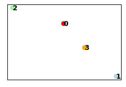

```python
# extract the longitude and latitude from the centroids
longitude, latitude = zip(*centroids)

# assign the colours and centroid numbers
colours = ['red', 'lightblue', 'palegreen', 'orange']
labels=['0', '1', '2', '3']

# create a small plot of centroids
plt.figure(figsize=(3, 2))
plt.scatter(longitude, latitude, c=colours)

# remove axis ticks (normalised so not useful)
plt.xticks([])
plt.yticks([])

# add the labels above each point
for i, (x, y) in enumerate(zip(longitude, latitude)):
    plt.text(x, y, labels[i], fontweight = 550, va='center' )

# show the plot
plt.show()
```

To visualise their approximate locations, we can inspect the centroids on a quick plot. The axes have been removed because they represent normalised data, and therefore, they are not accurate representations of longitude and latitude.

### Add a new column to the dataset with cluster assignments for each listing

```python
# create a new column in the data with the cluster assignments
hawaii_bnb['cluster'] = cluster_assignments

# display the columns with their clusters
display(hawaii_bnb[required_cols + ['cluster']])
```

|  | latitude | longitude | price | room_type | cluster |
| --- | --- | --- | --- | --- | --- |
| 0 | 20.027400 | -155.702000 | 185.0 | Entire home/apt | 2 |
| 1 | 19.430810 | -155.880690 | 95.0 | Entire home/apt | 2 |
| 2 | 19.441490 | -154.915270 | 134.0 | Private room | 2 |
| 3 | 21.582250 | -158.136140 | NaN | Entire home/apt | 3 |
| 4 | 19.512250 | -154.910200 | 98.0 | Entire home/apt | 2 |
| ... | ... | ... | ... | ... | ... |
| 35290 | 21.330518 | -158.122404 | 700.0 | Entire home/apt | 3 |
| 35291 | 21.570560 | -158.120060 | 174.0 | Entire home/apt | 3 |
| 35292 | 21.275250 | -157.821810 | 200.0 | Entire home/apt | 3 |
| 35293 | 21.284374 | -157.838440 | 353.0 | Entire home/apt | 3 |
| 35294 | 21.284374 | -157.838440 | 162.0 | Entire home/apt | 3 |

35295 rows × 5 columns

### Save the updated dataset as a CSV file

```python
# saved into 'data' folder
hawaii_bnb.to_csv('data/hawaii_clustered.csv', index=False)
```

# Part 3: Data Analysis

### Load the the Airbnb dataset as a CSV file from your local machine

```python
# load the new csv from data folder on my device
hawaii_bnb_clustered = pd.read_csv("data/hawaii_clustered.csv")

# display the first 3 entries
display(hawaii_bnb_clustered.head(3))
```

|  | id | name | host_id | host_name | neighbourhood_group | neighbourhood | latitude | longitude | room_type | price | minimum_nights | number_of_reviews | last_review | reviews_per_month | calculated_host_listings_count | availability_365 | number_of_reviews_ltm | license | cluster |
| --- | --- | --- | --- | --- | --- | --- | --- | --- | --- | --- | --- | --- | --- | --- | --- | --- | --- | --- | --- |
| 0 | 5269 | Upcountry Hospitality in the 'Auwai Suite | 7620 | Lea & Pat | Hawaii | South Kohala | 20.02740 | -155.70200 | Entire home/apt | 185.0 | 3 | 38 | 2024-07-21 | 0.23 | 2 | 266 | 11 | 119-269-5808-01R | 2 |
| 1 | 5387 | Hale Koa Studio & 1 Bedroom Units!! | 7878 | Edward | Hawaii | South Kona | 19.43081 | -155.88069 | Entire home/apt | 95.0 | 5 | 224 | 2024-08-15 | 1.26 | 2 | 241 | 13 | TA-163-133-0304-01 | 2 |
| 2 | 5480 | Isle Of You Naturally Farm Retreat | 8145 | Normand | Hawaii | Puna | 19.44149 | -154.91527 | Private room | 134.0 | 2 | 0 | NaN | NaN | 3 | 365 | 0 | NaN | 2 |

### Calculate median and mean prices by each cluster

```python
# group the data by cluster
# calculate the median price from the grouped cluster
medians = hawaii_bnb_clustered.groupby('cluster').median()['price']

# calculate the mean price from the grouped cluster
means = hawaii_bnb_clustered.groupby('cluster').mean()['price']

# print the results
print('The median prices broken down by:', round(medians))
print('\n\nThe mean prices broken down by:', round(means))
```

```
The median prices broken down by: cluster
0    261.0
1    287.0
2    193.0
3    185.0
Name: price, dtype: float64


The mean prices broken down by: cluster
0    422.0
1    462.0
2    307.0
3    323.0
Name: price, dtype: float64
```

### Do you find any difference between the two measures?

The difference between the median and mean prices for each cluster highlights the skewness of the price distributions:

**Cluster 0:**  
Median = 261  
Mean = 422  
The mean is substantially higher than the median, indicating a right-skewed distribution. This suggests that a few very high prices are pulling the mean up, while most prices are much lower.

**Cluster 1:**  
Median = 287  
Mean = 462 The same pattern is observed here, with the mean much higher than the median. This also indicates a right-skewed distribution.

**Cluster 2:**  
Median = 193  
Mean = 307  
The mean remains higher than the median, showing the presence of outliers driving the distribution toward higher values.

**Cluster 3:**  
Median = 185  
Mean = 323  
Similar to other clusters, the mean is much higher than the median, pointing to right skewness.

### Interpretation

The consistent pattern across all clusters, where the mean is much higher than the median indicates right-skewed price distributions. This suggests that a small number of high outlier prices are impacting the average, while the median remains a more accurate measure of the central tendency.

### Count number of different types of accommodation by each cluster.

```python
# create pivot table
accomm_pivot_table = hawaii_bnb_clustered.pivot_table(
                    index='cluster',
                    columns='room_type',
                    aggfunc='size', # count total number
                    fill_value=0 )# fill NAs with 0

# display the pivot table
display(accomm_pivot_table)
```

| room_type cluster | Entire home/apt | Hotel room | Private room | Shared room |
| --- | --- | --- | --- | --- |
| 0 | 9762 | 155 | 862 | 9 |
| 1 | 5172 | 97 | 478 | 0 |
| 2 | 7493 | 29 | 1029 | 16 |
| 3 | 8677 | 140 | 1363 | 13 |

### Are there any differences across clusters?

Clusters 0 and 3 have the highest number of hotel room listings compared to the other clusters. This may suggest that these clusters correspond to the most popular destinations for holidaymakers, as hotel rooms are typically in demand in areas with high tourism activity.

Clusters 2 and 3 both have notable counts of shared room listings. This could potentially indicate areas with a higher concentration of hostels or backpacker accommodation options, catering to budget-conscious travellers.

### Try plotting the positions of listings (using longitude as x-axis and latitude as y-axis) and colouring the points by cluster assignment.

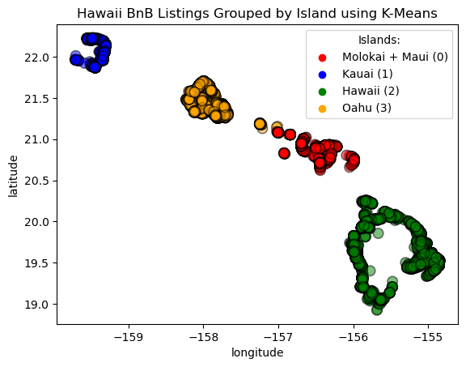

```python
# define the colours for the clusters
colours = ['red', 'blue', 'green', 'orange']

# assign colours to the numbers
cols = [colours[cluster] for cluster in cluster_assignments]

# scatter the points with the colours
plt.scatter(hawaii_bnb_clustered['longitude'],
            hawaii_bnb_clustered['latitude'] ,
            color = cols , # assigned colours
            alpha=0.5, # make the points slightly transparent
            edgecolor='black',
            linewidth=1.2,
            s=80) # point size


# labels for this islands
legend_labels = ['Molokai + Maui', 'Kauai','Hawaii', 'Oahu']

# blank scatter for legend
for i, label in enumerate(legend_labels):

    # assign the name and index number to each colour
    plt.scatter([], [], color=colours[i], label=f"{label} ({i})")

# add axis labels and title
plt.xlabel('longitude')
plt.ylabel('latitude')
plt.title('Hawaii BnB Listings Grouped by Island using K-Means')

# show legend with title
plt.legend(title='Islands:')

# display the plot
plt.show()
```

[figure not shown]